# Lab 33

Luz Yolanda Rivera

3/4/2021

CARACTERISTICAS DE LOS AUTOS Base de datos del propio Rstudio que se llama mtcars, para verla ?mtcars

```r
head(mtcars)
```

```
##                    mpg cyl disp  hp drat    wt  qsec vs am gear carb
## Mazda RX4         21.0   6  160 110 3.90 2.620 16.46  0  1    4    4
## Mazda RX4 Wag     21.0   6  160 110 3.90 2.875 17.02  0  1    4    4
## Datsun 710        22.8   4  108  93 3.85 2.320 18.61  1  1    4    1
## Hornet 4 Drive    21.4   6  258 110 3.08 3.215 19.44  1  0    3    1
## Hornet Sportabout 18.7   8  360 175 3.15 3.440 17.02  0  0    3    2
## Valiant           18.1   6  225 105 2.76 3.460 20.22  1  0    3    1
```

identificar qué tipos de datos se tienen

```r
class(mtcars)
```

```
## [1] "data.frame"
```

vemos que mtcars es un data.frame, por lo tanto lo convertimos en matriz para poder hacer un mapa de calor llamada mtcars_matrix

```r
mtcars_matrix <- data.matrix(mtcars)
```

verificamos que la conversión a matriz se realizó, preguntando con class, qué tipo de datos son

```r
class(mtcars_matrix)
```

```
## [1] "matrix" "array"
```

hacer el mapa de calor con la función heatmap

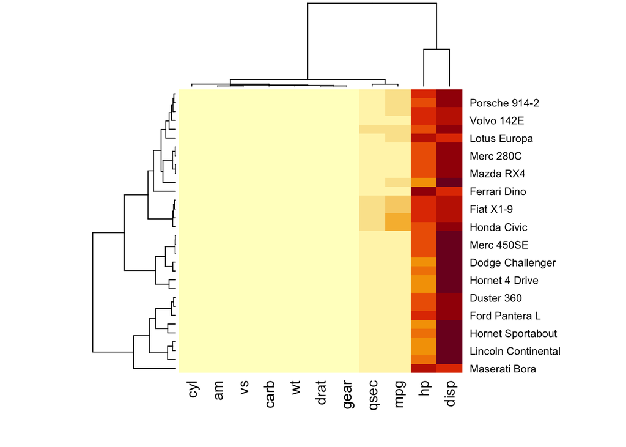

```r
heatmap(mtcars_matrix)
```

¿Se parece a lo que esperabas? Mire la página de ayuda de la función y lea la descripción del scale argumento de heatmap

```r
?heatmap
```

La escala es importante: los valores deben centrarse y escalarse en filas o columnas. En nuestro caso, queremos visualizar altibajos en cada variable, que está en columnas.

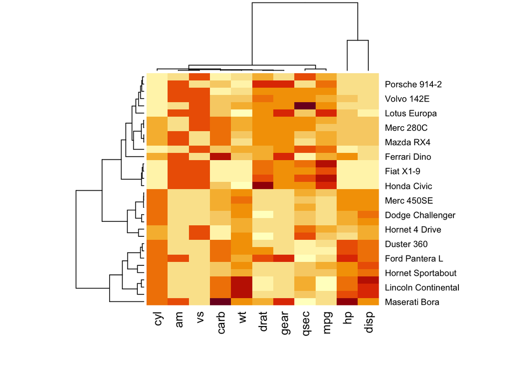

```r
heatmap(mtcars_matrix, scale = "colum")
```

crear nuestra propia paleta-gama de colores o coloreta, del color más ligero al más intenso

```r
colores_blue<- colorRampPalette(c ("lightblue", "cornflowerblue", "navyblue" )) (256)
```

La misma instrucción ahora le indico que los colores col, serán los de la gama de colores que cree blue vamos como Maserati Bora tiene máyor valor en caballos de fuerza que las otras marcas de coches con AMBOS denogramas por default, se ordenan las variables por cluster de pertenencia

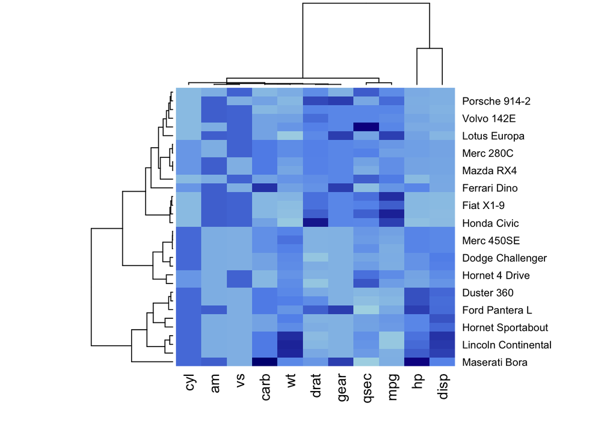

```r
heatmap(mtcars_matrix,
        scale = "colum",
        col= colores_blue)
```

Eliminar dendrogramas El dendrograma de columna realmente no tiene sentido para este conjunto de datos, es el horizontal no nos interesa el dendograma de las características, no interesa el de los tipos de coche Rowv y Colvse puede configurar para NAeliminar dendrogramas, lo que también significa que los datos no se reorganizarn de acuerdo con el método de agrupación. NOS INTERESA COMO SE CLUSTEAN LOS TIPOS DE COCHE, NO LAS CARACTERÍSTICAS DE LOS COCHES POR QUE LOS DATOS NO ESTAN NORMALIZADOS

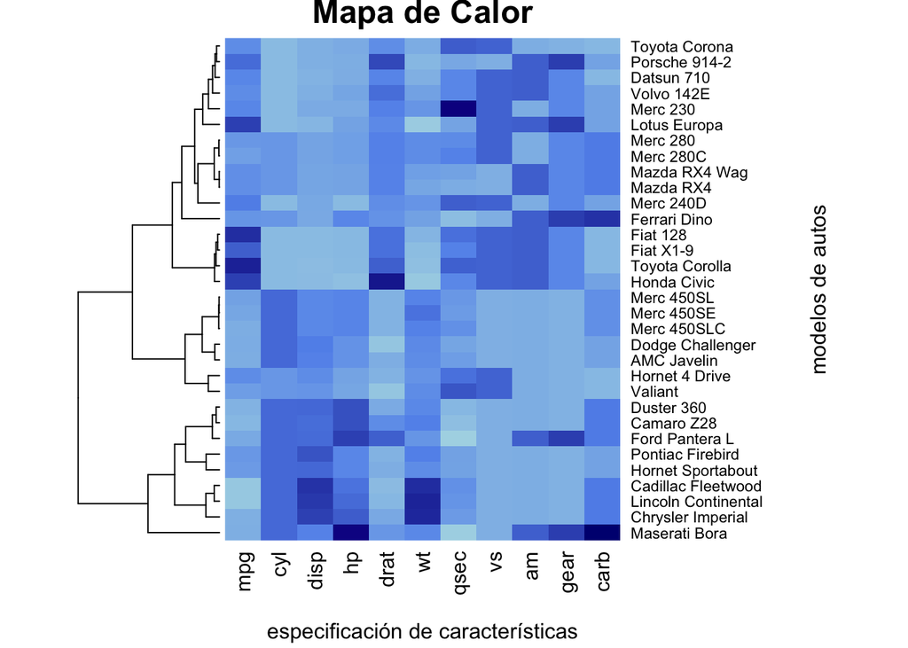

```r
heatmap(mtcars_matrix,
        scale = "colum",
        col= colores_blue,
        Colv = NA ,
        margins = c(5 , 10),
        xlab = "especificación de características",
        ylab = "modelos de autos",
        main = "Mapa de Calor")
```

puedo checar los nombres de las columnas de mi matriz y veo que no hay cambios. se respeta el orden de las columnas, porque se borr? el dendrograma de las columnas, ya no se ordena por cluster no se respeta el orden de los renglones, porque estos si tienen clusteo

```r
colnames(mtcars_matrix)
```

```
##  [1] "mpg"  "cyl"  "disp" "hp"   "drat" "wt"   "qsec" "vs"   "am"   "gear"
## [11] "carb"
```

#paletas por defecto # rainbow, heat.colors, terrain.colors, topo.colors, cm.colors #llamamos a librería a viridis

```r
library(viridis)
```

cambiamos de color a “viridis”

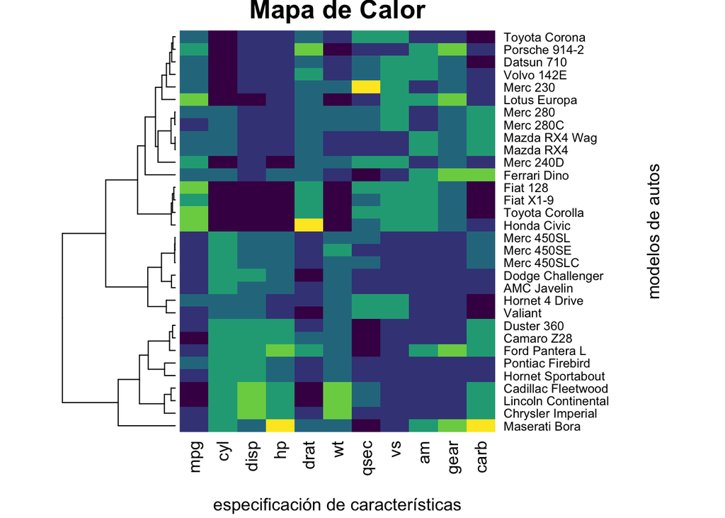

```r
heatmap(mtcars_matrix,
        scale = "colum",
        col= viridis_pal(option = "viridis") (6) ,
        Colv = NA ,
        margins = c(5 , 10),
        xlab = "especificación de características",
        ylab = "modelos de autos",
        main = "Mapa de Calor")
```

cambiamos ahora a magma

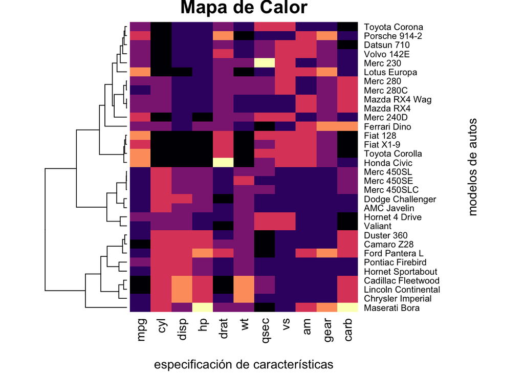

```r
heatmap(mtcars_matrix,
        scale = "colum",
        col= viridis_pal(option = "magma") (6) ,
        Colv = NA ,
        margins = c(5 , 10),
        xlab = "especificación de características",
        ylab = "modelos de autos",
        main = "Mapa de Calor")
```

cambiamos los colores a las opciones que tiene sin viridis col = viridis_pal(option = “viridis”) (6)) viridis, magma, plasma, cividis, inferno

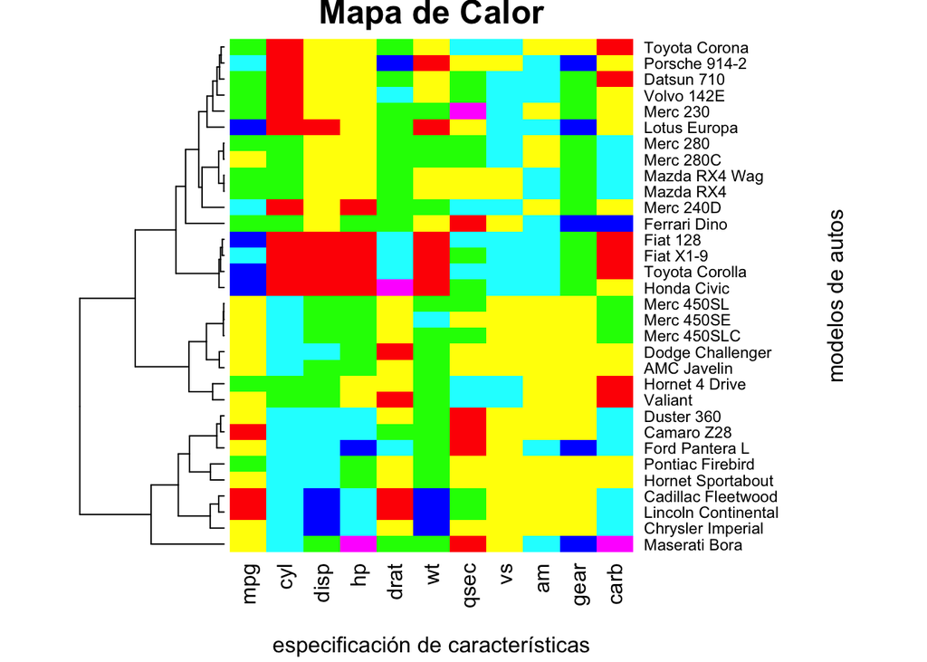

```r
heatmap(mtcars_matrix,
        scale = "colum",
        col= rainbow (6) ,
        Colv = NA ,
        margins = c(5 , 10),
        xlab = "especificación de características",
        ylab = "modelos de autos",
        main = "Mapa de Calor")
```

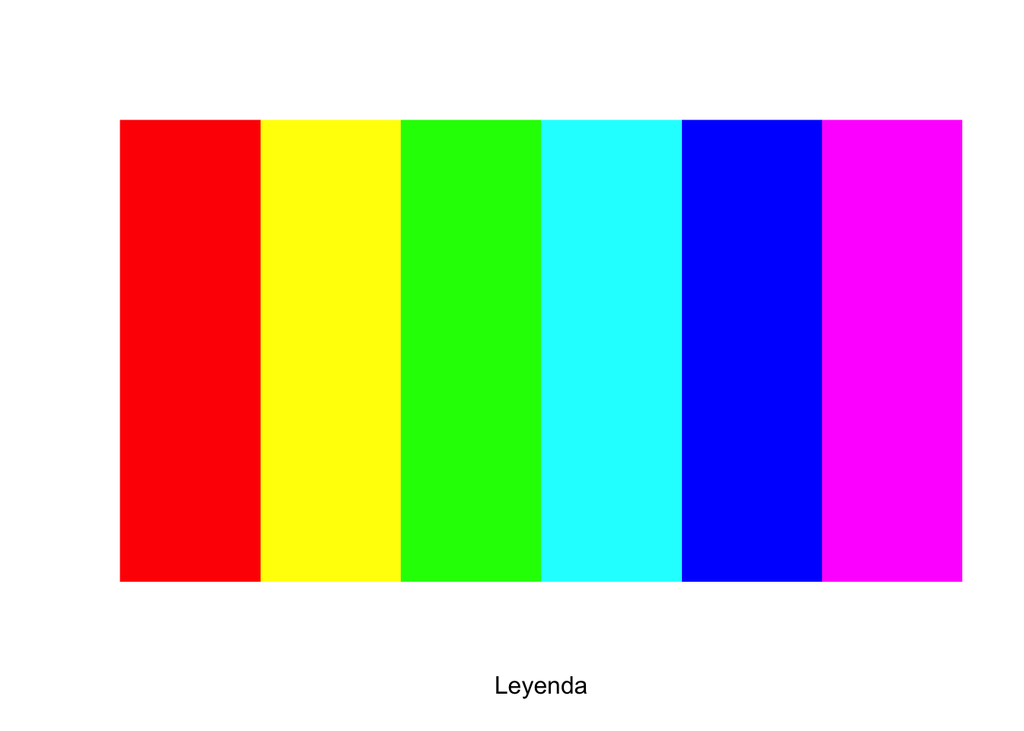

```r
image(1:6,1,as.matrix(1:6), col = rainbow (6), xlab="Leyenda", ylab="", xaxt="n", yaxt="n", bty="n")
```

llamamos datos a la matriz de mtcars

```r
datos <- mtcars
```

Para que las variables sean comparables bajo un mismo esquema de colores se estandarizan

```r
datos <- scale(datos)
```

graficar el denograma llamado modelo

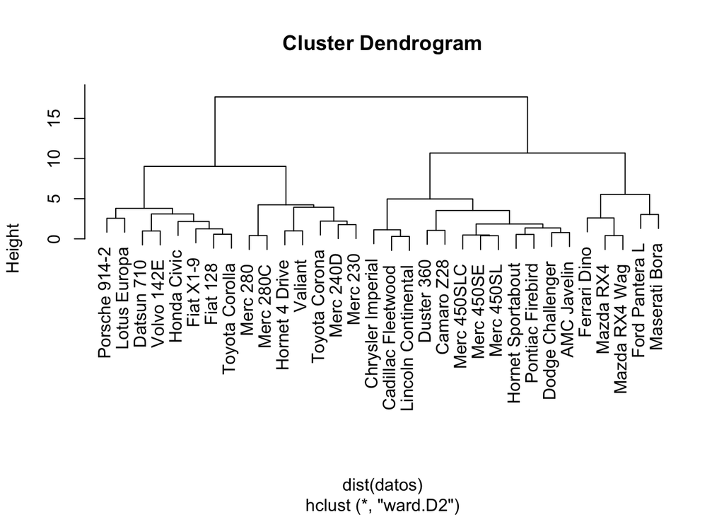

```r
modelo<- hclust(dist(datos), method = "ward.D2")
plot(modelo)
```